# Total Time Markdown

Lib

04/08/2020

```r
#Set seed for random number generation
set.seed(42)
knitr::opts_chunk$set(cache.extra = knitr::rand_seed)
```

# Research Questions

As readers do we predict upcoming information before it is encountered in order to better understand the unfolding discourse?

If prediction is not utilized do we rely on more on basic integration to understand an unfolding discourse context?

Do individual differences contribute to our ability to predict and/or integrate upcoming information? How do these contribute?

# Region 4: The question

Let’s have a look at various models for our critical region of interest, the question.

```r
#Let's have a look at region 4

#set condition as a factor
all_data_join$cond <- as.factor(all_data_join$cond)
# Throw away zeroes
all_data_join <- all_data_join %>% filter(R4 != 0)
```

## Eye-tracking only model

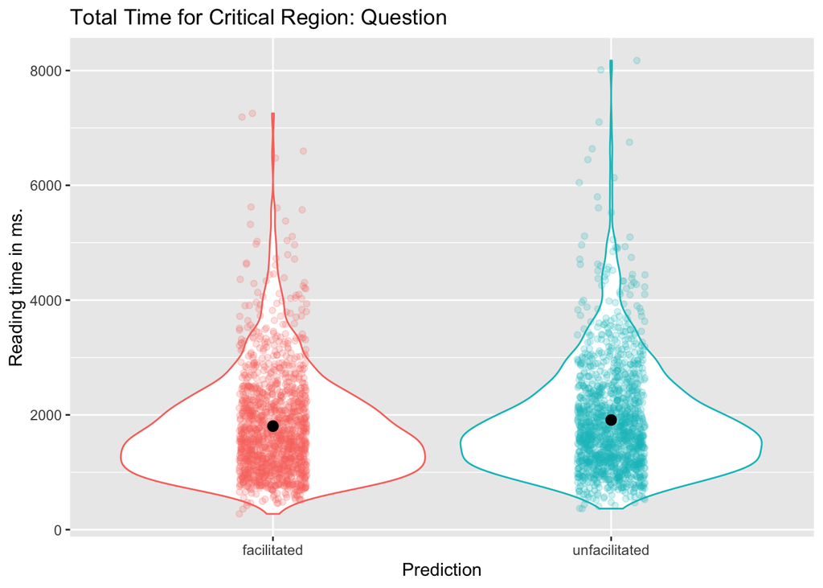

```r
#Let's have a look at region 4

#set condition as a factor
all_data_join$cond <- as.factor(all_data_join$cond)
# Throw away zeroes
all_data_join <- all_data_join %>% filter(R4 != 0)

#Visualisation
all_data_join %>%
  ggplot(aes(x = cond, y = R4, colour = cond)) + ggtitle("Total Time for Critical Region: Question") +
  labs(y = "Reading time in ms.", x = "Prediction") +
  geom_violin() +
  geom_jitter(alpha = .2, width = .1) +
  stat_summary(fun.data = "mean_cl_boot", colour = "black") +
  guides(colour = FALSE)
```

```r
#Descriptives
all_data_join %>%
  group_by(cond) %>%
  summarise(mean(R4), sd(R4))
```

```
## # A tibble: 2 x 3
##   cond          `mean(R4)` `sd(R4)`
##   <fct>              <dbl>    <dbl>
## 1 facilitated        1804.     908.
## 2 unfacilitated      1911.     967.
```

```r
# Model assuming normality of residuals maximal structure
#model.nullR4 <- lmer(R4 ~ (1 + cond | subj) + (1 + cond | item), all_data_join)
modelR4 <- lmer(R4 ~ cond + (1 + cond | subj) + (1 + cond | item), all_data_join)
summary(modelR4)
```

```
## Linear mixed model fit by REML. t-tests use Satterthwaite's method [
## lmerModLmerTest]
## Formula: R4 ~ cond + (1 + cond | subj) + (1 + cond | item)
##    Data: all_data_join
##
## REML criterion at convergence: 43201.2
##
## Scaled residuals:
##     Min      1Q  Median      3Q     Max
## -2.9580 -0.6286 -0.1686  0.3937  7.4459
##
## Random effects:
##  Groups   Name              Variance Std.Dev. Corr
##  subj     (Intercept)       310824.4 557.52
##           condunfacilitated    140.1  11.84   1.00
##  item     (Intercept)        61586.9 248.17
##           condunfacilitated  36930.9 192.17   -0.21
##  Residual                   498650.2 706.15
## Number of obs: 2686, groups:  subj, 84; item, 32
##
## Fixed effects:
##                   Estimate Std. Error      df t value Pr(>|t|)
## (Intercept)        1803.07      77.44   97.10  23.285   <2e-16 ***
## condunfacilitated   108.90      43.57   30.24   2.499   0.0181 *
## ---
## Signif. codes:  0 '***' 0.001 '**' 0.01 '*' 0.05 '.' 0.1 ' ' 1
##
## Correlation of Fixed Effects:
##             (Intr)
## condnfclttd -0.179
## convergence code: 0
## Model failed to converge with max|grad| = 0.0061659 (tol = 0.002, component 1)
```

```r
#anova(modelR4, model.nullR4)

#All the data for this model looks pretty normal.
check_model(modelR4)
```

```
## Not enough model terms in the conditional part of the model to check for multicollinearity.
```

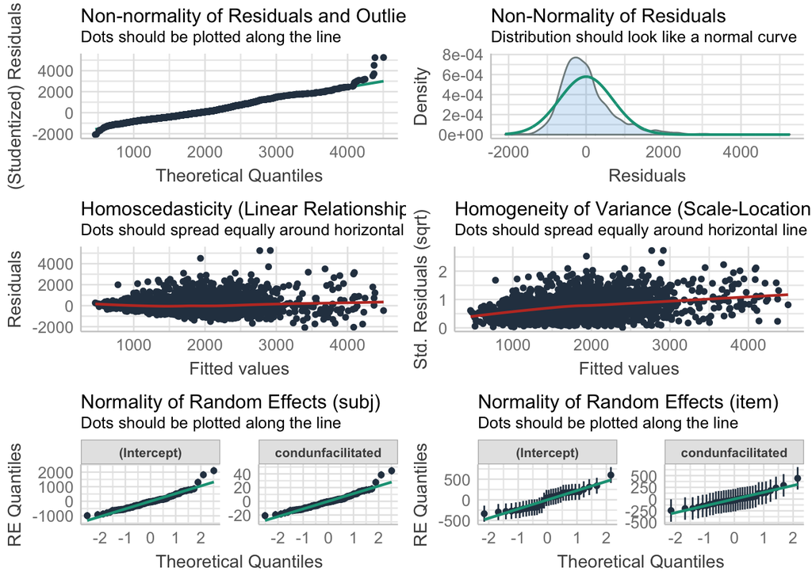

```r
#qqnorm(residuals(modelR4))
#qqline(residuals(modelR4))
#descdist(all_data_join$R4)
```

## Individual differences as controlling factors

```r
#Let's include some co-variates! Region 4

#Step 1: Scale the ID measures...
all_data_join$SRS_total_score_t <- scale(all_data_join$SRS_total_score_t)
all_data_join$EQ <- scale(all_data_join$EQ)
all_data_join$Total_reading_cluster <- scale(all_data_join$Total_reading_cluster)
all_data_join$Total_RAN <- scale(all_data_join$Total_RAN)
all_data_join$"WI _RPI" <- scale(all_data_join$"WI _RPI")
```

```r
# Model including covariates
model_alldatacov_R4 <- lmer(R4 ~ SRS_total_score_t + EQ + Total_reading_cluster + Total_RAN + cond + (1 | subj) +  (1 | item) , data = all_data_join, REML = TRUE)

#model_alldatacov_R4_null <- lmer(R4 ~ SRS_total_score_t + EQ + Total_reading_cluster + #Total_RAN +
#                               (1 + cond | subj) +  (1 + cond | item) , data = #all_data_join, REML = TRUE)

summary(model_alldatacov_R4)
```

```
## Linear mixed model fit by REML. t-tests use Satterthwaite's method [
## lmerModLmerTest]
## Formula: R4 ~ SRS_total_score_t + EQ + Total_reading_cluster + Total_RAN +
##     cond + (1 | subj) + (1 | item)
##    Data: all_data_join
##
## REML criterion at convergence: 42636.3
##
## Scaled residuals:
##     Min      1Q  Median      3Q     Max
## -3.0436 -0.6141 -0.1575  0.4018  7.3976
##
## Random effects:
##  Groups   Name        Variance Std.Dev.
##  subj     (Intercept) 320738   566.3
##  item     (Intercept)  59196   243.3
##  Residual             502973   709.2
## Number of obs: 2654, groups:  subj, 83; item, 32
##
## Fixed effects:
##                       Estimate Std. Error       df t value Pr(>|t|)
## (Intercept)           1802.035     78.063  107.673  23.084  < 2e-16 ***
## SRS_total_score_t       12.133     81.418   77.999   0.149   0.8819
## EQ                      -6.741     81.433   77.999  -0.083   0.9342
## Total_reading_cluster   -2.595     65.887   78.005  -0.039   0.9687
## Total_RAN              126.901     66.118   78.016   1.919   0.0586 .
## condunfacilitated      108.097     27.535 2539.088   3.926 8.87e-05 ***
## ---
## Signif. codes:  0 '***' 0.001 '**' 0.01 '*' 0.05 '.' 0.1 ' ' 1
##
## Correlation of Fixed Effects:
##             (Intr) SRS___ EQ     Ttl_r_ Tt_RAN
## SRS_ttl_sc_ -0.001
## EQ           0.004  0.627
## Ttl_rdng_cl -0.007  0.008 -0.007
## Total_RAN   -0.001 -0.058 -0.056  0.263
## condnfclttd -0.176  0.000  0.000  0.000  0.000
```

Our condition is significant.

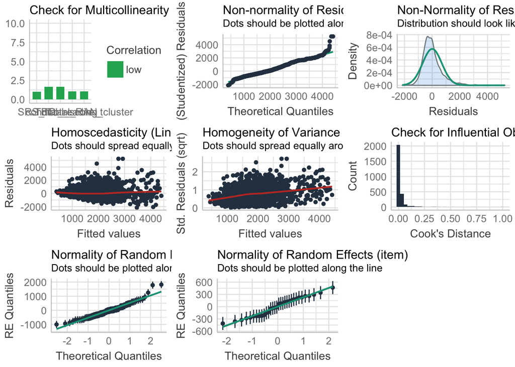

```r
#anova(model_alldatacov_R4_null, model_alldatacov_R4)
check_model(model_alldatacov_R4)
```

```r
ranef(model_alldatacov_R4)
```

```
## $subj
##     (Intercept)
## 1     40.565844
## 10  -678.016027
## 11   317.107683
## 12   321.313563
## 13  -377.599627
## 14  -203.856315
## 15  -236.468912
## 16   261.882305
## 17   486.749053
## 18   236.371796
## 19   -35.717708
## 2    573.346073
## 20   471.686123
```

[output cut: 107 more lines]

# summary of Results for region 4, the question.

After controlling for individual differences participants are significantly faster at reading facilitated conditions compared to un-facilitated conditions where they take an extra 108 milliseconds to complete their Total Time read through of the text. We have controlled for our IDS which have no effect reading times between conditions.

# Correlations

```r
library(Hmisc)
#Measuring Correlations
EQscore <- all_data_join %>% group_by(subj) %>% summarise(mean = mean(EQ)) %>% pull(mean)
SRS2 <- all_data_join %>% group_by(subj) %>% summarise(mean = mean(SRS_total_score_t)) %>% pull(mean)
WRMT <- all_data_join %>% group_by(subj) %>% summarise(mean = mean(Total_reading_cluster)) %>% pull(mean)
RAN <- all_data_join %>% group_by(subj) %>% summarise(mean = mean(Total_RAN)) %>% pull(mean)
rcorr(EQscore, SRS2)
```

```
##       x     y
## x  1.00 -0.63
## y -0.63  1.00
##
## n= 84
##
##
## P
##   x  y
## x     0
## y  0
```

```r
rcorr(EQscore, WRMT)
```

```
##   x y
## x 1 0
## y 0 1
##
## n= 84
##
##
## P
##   x      y
## x        0.9673
## y 0.9673
```

```r
rcorr(EQscore, RAN)
```

```
##      x    y
## x 1.00 0.02
## y 0.02 1.00
##
## n
##    x  y
## x 84 83
## y 83 83
##
## P
##   x      y
## x        0.8428
## y 0.8428
```

```r
rcorr(SRS2, WRMT)
```

```
##       x     y
## x  1.00 -0.02
## y -0.02  1.00
##
## n= 84
##
##
## P
##   x      y
## x        0.8494
## y 0.8494
```

```r
rcorr(SRS2, RAN)
```

```
##      x    y
## x 1.00 0.03
## y 0.03 1.00
##
## n
##    x  y
## x 84 83
## y 83 83
##
## P
##   x      y
## x        0.7566
## y 0.7566
```

```r
rcorr(WRMT, RAN)
```

```
##       x     y
## x  1.00 -0.26
## y -0.26  1.00
##
## n
##    x  y
## x 84 83
## y 83 83
##
## P
##   x      y
## x        0.0159
## y 0.0159
```

# Region 5: The reply

Let’s have a look at various models for our post-critical region of interest, the reply.

## Eye-tracking only model

```r
#set condition as a factor
all_data_join$cond <- as.factor(all_data_join$cond)
# Throw away zeroes
all_data_join <- all_data_join %>% filter(R5 != 0)
```

## Eye-tracking only model

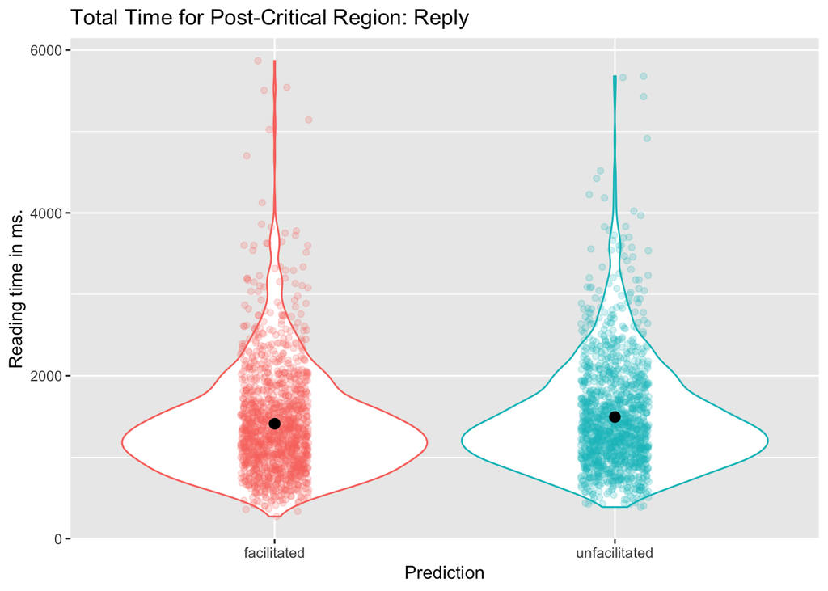

```r
#Let's have a look at region 4

#set condition as a factor
all_data_join$cond <- as.factor(all_data_join$cond)
# Throw away zeroes
all_data_join <- all_data_join %>% filter(R5 != 0)

#Visualisation
all_data_join %>%
  ggplot(aes(x = cond, y = R5, colour = cond)) + ggtitle("Total Time for Post-Critical Region: Reply") +
  labs(y = "Reading time in ms.", x = "Prediction") +
  geom_violin() +
  geom_jitter(alpha = .2, width = .1) +
  stat_summary(fun.data = "mean_cl_boot", colour = "black") +
  guides(colour = FALSE)
```

```r
#Descriptives
all_data_join %>%
  group_by(cond) %>%
  summarise(mean(R5), sd(R5))
```

```
## # A tibble: 2 x 3
##   cond          `mean(R5)` `sd(R5)`
##   <fct>              <dbl>    <dbl>
## 1 facilitated        1411.     662.
## 2 unfacilitated      1494.     675.
```

```r
# Model assuming normality of residuals maximal structure
#model.nullR5 <- lmer(R5 ~ (1 | subj) + (1 | item), all_data_join)
modelR5 <- lmer(R5 ~ cond + (1 | subj) + (1 | item), all_data_join)
summary(modelR5)
```

```
## Linear mixed model fit by REML. t-tests use Satterthwaite's method [
## lmerModLmerTest]
## Formula: R5 ~ cond + (1 | subj) + (1 | item)
##    Data: all_data_join
##
## REML criterion at convergence: 41373.3
##
## Scaled residuals:
##     Min      1Q  Median      3Q     Max
## -2.3581 -0.6085 -0.1771  0.4044  8.3066
##
## Random effects:
##  Groups   Name        Variance Std.Dev.
##  subj     (Intercept) 147785   384.4
##  item     (Intercept)  48087   219.3
##  Residual             254478   504.5
## Number of obs: 2686, groups:  subj, 84; item, 32
##
## Fixed effects:
##                   Estimate Std. Error      df t value Pr(>|t|)
## (Intercept)        1411.52      58.75   96.28  24.026  < 2e-16 ***
## condunfacilitated    81.49      19.47 2570.18   4.185 2.95e-05 ***
## ---
## Signif. codes:  0 '***' 0.001 '**' 0.01 '*' 0.05 '.' 0.1 ' ' 1
##
## Correlation of Fixed Effects:
##             (Intr)
## condnfclttd -0.166
```

```r
#anova(modelR5, model.nullR5)

#All the data for this model looks pretty normal.
check_model(modelR5)
```

```
## Not enough model terms in the conditional part of the model to check for multicollinearity.
```

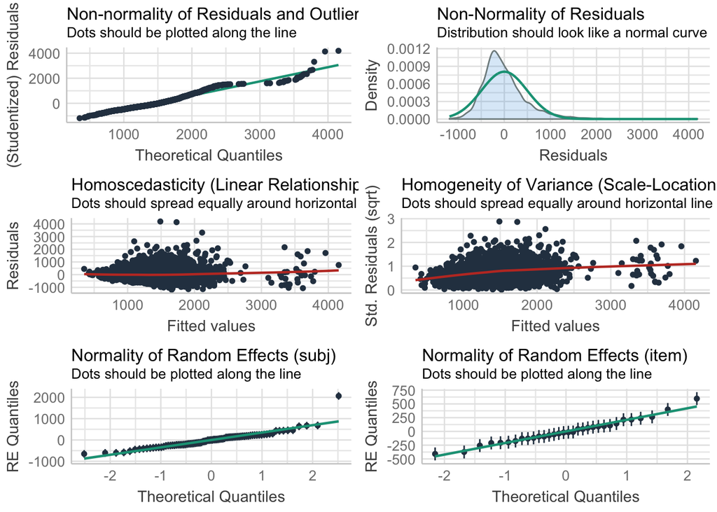

```r
#qqnorm(residuals(modelR5))
#qqline(residuals(modelR5))
#descdist(all_data_join$R5)
```

## Individual differences as controlling factors

```r
#Let's include some co-variates! Region 4

#Step 1: Scale the ID measures...
all_data_join$SRS_total_score_t <- scale(all_data_join$SRS_total_score_t)
all_data_join$EQ <- scale(all_data_join$EQ)
all_data_join$Total_reading_cluster <- scale(all_data_join$Total_reading_cluster)
all_data_join$Total_RAN <- scale(all_data_join$Total_RAN)
all_data_join$"WI _RPI" <- scale(all_data_join$"WI _RPI")
```

```r
# Model including covariates
model_alldatacov_R5 <- lmer(R5 ~ SRS_total_score_t + EQ + Total_reading_cluster + Total_RAN + cond + (1 | subj) +  (1 | item) , data = all_data_join, REML = TRUE)

#model_alldatacov_R5_null <- lmer(R5 ~ SRS_total_score_t + EQ + Total_reading_cluster + #Total_RAN +
#                               (1 + cond | subj) +  (1 + cond | item) , data = #all_data_join, REML = TRUE)

summary(model_alldatacov_R5)
```

```
## Linear mixed model fit by REML. t-tests use Satterthwaite's method [
## lmerModLmerTest]
## Formula: R5 ~ SRS_total_score_t + EQ + Total_reading_cluster + Total_RAN +
##     cond + (1 | subj) + (1 | item)
##    Data: all_data_join
##
## REML criterion at convergence: 40705.5
##
## Scaled residuals:
##     Min      1Q  Median      3Q     Max
## -2.4223 -0.6177 -0.1794  0.4127  8.5125
##
## Random effects:
##  Groups   Name        Variance Std.Dev.
##  subj     (Intercept) 146916   383.3
##  item     (Intercept)  46791   216.3
##  Residual             241604   491.5
## Number of obs: 2654, groups:  subj, 83; item, 32
##
## Fixed effects:
##                       Estimate Std. Error      df t value Pr(>|t|)
## (Intercept)            1408.71      58.43   95.38  24.107  < 2e-16 ***
## SRS_total_score_t       -19.99      55.17   78.00  -0.362   0.7181
## EQ                      -52.70      55.18   78.00  -0.955   0.3425
## Total_reading_cluster    26.83      44.64   78.00   0.601   0.5496
## Total_RAN                94.97      44.80   78.02   2.120   0.0372 *
## condunfacilitated        80.67      19.08 2539.05   4.227 2.45e-05 ***
## ---
## Signif. codes:  0 '***' 0.001 '**' 0.01 '*' 0.05 '.' 0.1 ' ' 1
##
## Correlation of Fixed Effects:
##             (Intr) SRS___ EQ     Ttl_r_ Tt_RAN
## SRS_ttl_sc_ -0.001
## EQ           0.003  0.627
## Ttl_rdng_cl -0.007  0.008 -0.007
## Total_RAN   -0.001 -0.058 -0.056  0.263
## condnfclttd -0.163  0.000  0.000  0.000  0.000
```

So Total_RAN and our condition are significant.

If we drop the Total_RAN the effect of condition is still there (see below) - suggesting to me that the effect of Total_RAN is separate from the effect of condition.

```r
model_alldatacov_R5_noRAN <- lmer(R5 ~ SRS_total_score_t + EQ + Total_reading_cluster + cond + (1 | subj) +  (1 | item) , data = all_data_join, REML = TRUE)
summary(model_alldatacov_R5_noRAN)
```

```
## Linear mixed model fit by REML. t-tests use Satterthwaite's method [
## lmerModLmerTest]
## Formula: R5 ~ SRS_total_score_t + EQ + Total_reading_cluster + cond +
##     (1 | subj) + (1 | item)
##    Data: all_data_join
##
## REML criterion at convergence: 41344
##
## Scaled residuals:
##     Min      1Q  Median      3Q     Max
## -2.3578 -0.6083 -0.1753  0.4027  8.3059
##
## Random effects:
##  Groups   Name        Variance Std.Dev.
##  subj     (Intercept) 152120   390.0
##  item     (Intercept)  48087   219.3
##  Residual             254478   504.5
## Number of obs: 2686, groups:  subj, 84; item, 32
##
## Fixed effects:
##                        Estimate Std. Error        df t value Pr(>|t|)
## (Intercept)           1411.5043    59.1879   96.0912  23.848  < 2e-16 ***
## SRS_total_score_t      -13.7405    56.0601   79.9925  -0.245    0.807
## EQ                     -44.9251    56.0466   79.9931  -0.802    0.425
## Total_reading_cluster   -0.4633    43.6813   79.9931  -0.011    0.992
## condunfacilitated       81.4925    19.4726 2570.1770   4.185 2.95e-05 ***
## ---
## Signif. codes:  0 '***' 0.001 '**' 0.01 '*' 0.05 '.' 0.1 ' ' 1
##
## Correlation of Fixed Effects:
##             (Intr) SRS___ EQ     Ttl_r_
## SRS_ttl_sc_  0.000
## EQ           0.000  0.627
## Ttl_rdng_cl  0.000  0.023  0.011
## condnfclttd -0.164  0.000  0.000  0.000
```

Does Total_RAN interact with our condition? No (see below.)

```r
model_alldatacov_R5_RAN_int <- lmer(R5 ~ SRS_total_score_t + EQ + Total_reading_cluster + Total_RAN + cond + cond:Total_RAN + (1 | subj) +  (1 | item) , data = all_data_join, REML = TRUE)
summary(model_alldatacov_R5_RAN_int)
```

```
## Linear mixed model fit by REML. t-tests use Satterthwaite's method [
## lmerModLmerTest]
## Formula: R5 ~ SRS_total_score_t + EQ + Total_reading_cluster + Total_RAN +
##     cond + cond:Total_RAN + (1 | subj) + (1 | item)
##    Data: all_data_join
##
## REML criterion at convergence: 40697.7
##
## Scaled residuals:
##     Min      1Q  Median      3Q     Max
## -2.4249 -0.6207 -0.1809  0.4125  8.5111
##
## Random effects:
##  Groups   Name        Variance Std.Dev.
##  subj     (Intercept) 146911   383.3
##  item     (Intercept)  46778   216.3
##  Residual             241693   491.6
## Number of obs: 2654, groups:  subj, 83; item, 32
##
## Fixed effects:
##                             Estimate Std. Error       df t value Pr(>|t|)
## (Intercept)                 1408.711     58.431   95.389  24.109  < 2e-16 ***
## SRS_total_score_t            -19.990     55.166   77.998  -0.362   0.7181
## EQ                           -52.703     55.176   77.998  -0.955   0.3424
## Total_reading_cluster         26.825     44.642   78.004   0.601   0.5497
## Total_RAN                     92.308     45.813   85.317   2.015   0.0471 *
## condunfacilitated             80.674     19.087 2538.054   4.227 2.46e-05 ***
## Total_RAN:condunfacilitated    5.319     19.123 2539.109   0.278   0.7809
## ---
## Signif. codes:  0 '***' 0.001 '**' 0.01 '*' 0.05 '.' 0.1 ' ' 1
##
## Correlation of Fixed Effects:
##             (Intr) SRS___ EQ     Ttl_r_ Tt_RAN cndnfc
## SRS_ttl_sc_ -0.001
## EQ           0.003  0.627
## Ttl_rdng_cl -0.007  0.008 -0.007
## Total_RAN   -0.001 -0.056 -0.055  0.258
## condnfclttd -0.163  0.000  0.000  0.000  0.000
## Ttl_RAN:cnd  0.000  0.000  0.000  0.000 -0.209  0.001
```

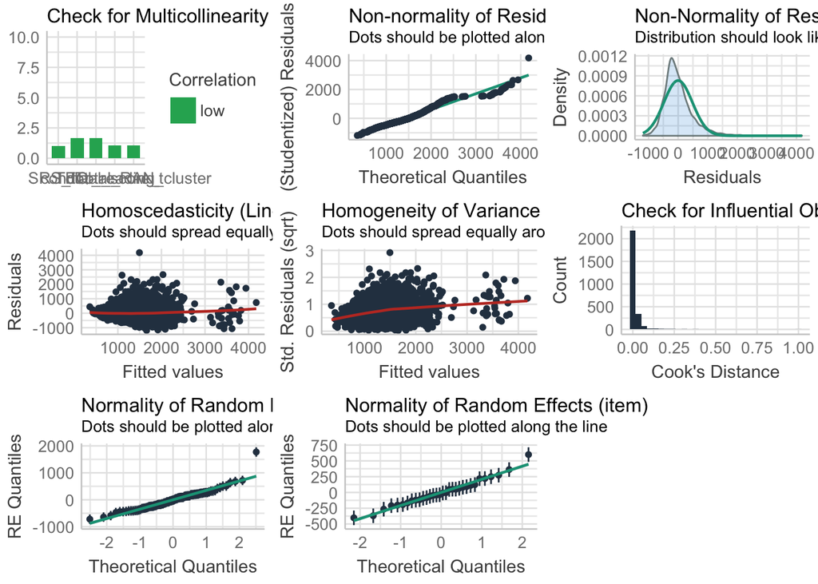

```r
#anova(model_alldatacov_R5_null, model_alldatacov_R5)
check_model(model_alldatacov_R5)
```

```r
ranef(model_alldatacov_R5)
```

```
## $subj
##     (Intercept)
## 1    87.6478134
## 10 -430.0820521
## 11   88.8855426
## 12  191.8165357
## 13 -293.9924604
## 14 -206.8651947
## 15  -39.3081601
## 16   83.4546371
## 17  321.3652991
## 18  137.1636274
## 19  -23.8042562
## 2   244.5809362
## 20  210.4752694
```

[output cut: 107 more lines]

Regardless of whether the individual predictors are present/absent, the effect of our condition is pretty much the same - suggesting the variance explained by our experimental manipulation doesn’t overlap with the variance explained by our individual difference measures.